# Risk Factor Analysis

## Outcome Variable

**Outcome Variable:** ever_wasted

## Predictor Variables

**Intervention Variable:** fage

**Adjustment Set:**

unadjusted

## Stratifying Variables

The analysis was stratified on these variable(s):

- agecat
- studyid
- country

## Data Summary

| agecat | studyid | country | fage | ever_wasted | n_cell | n | outcome_variable |
| --- | --- | --- | --- | --- | --- | --- | --- |
| 0-24 months | ki0047075b-MAL-ED | BANGLADESH | >=38 | 0 | 46 | 151 | ever_wasted |
| 0-24 months | ki0047075b-MAL-ED | BANGLADESH | >=38 | 1 | 23 | 151 | ever_wasted |
| 0-24 months | ki0047075b-MAL-ED | BANGLADESH | <32 | 0 | 15 | 151 | ever_wasted |
| 0-24 months | ki0047075b-MAL-ED | BANGLADESH | <32 | 1 | 15 | 151 | ever_wasted |
| 0-24 months | ki0047075b-MAL-ED | BANGLADESH | [32-38) | 0 | 39 | 151 | ever_wasted |
| 0-24 months | ki0047075b-MAL-ED | BANGLADESH | [32-38) | 1 | 13 | 151 | ever_wasted |
| 0-24 months | ki0047075b-MAL-ED | BRAZIL | >=38 | 0 | 30 | 79 | ever_wasted |
| 0-24 months | ki0047075b-MAL-ED | BRAZIL | >=38 | 1 | 0 | 79 | ever_wasted |
| 0-24 months | ki0047075b-MAL-ED | BRAZIL | <32 | 0 | 15 | 79 | ever_wasted |
| 0-24 months | ki0047075b-MAL-ED | BRAZIL | <32 | 1 | 3 | 79 | ever_wasted |
| 0-24 months | ki0047075b-MAL-ED | BRAZIL | [32-38) | 0 | 28 | 79 | ever_wasted |
| 0-24 months | ki0047075b-MAL-ED | BRAZIL | [32-38) | 1 | 3 | 79 | ever_wasted |
| 0-24 months | ki0047075b-MAL-ED | INDIA | >=38 | 0 | 25 | 161 | ever_wasted |
| 0-24 months | ki0047075b-MAL-ED | INDIA | >=38 | 1 | 11 | 161 | ever_wasted |
| 0-24 months | ki0047075b-MAL-ED | INDIA | <32 | 0 | 20 | 161 | ever_wasted |
| 0-24 months | ki0047075b-MAL-ED | INDIA | <32 | 1 | 33 | 161 | ever_wasted |
| 0-24 months | ki0047075b-MAL-ED | INDIA | [32-38) | 0 | 36 | 161 | ever_wasted |
| 0-24 months | ki0047075b-MAL-ED | INDIA | [32-38) | 1 | 36 | 161 | ever_wasted |
| 0-24 months | ki0047075b-MAL-ED | NEPAL | >=38 | 0 | 13 | 79 | ever_wasted |
| 0-24 months | ki0047075b-MAL-ED | NEPAL | >=38 | 1 | 4 | 79 | ever_wasted |
| 0-24 months | ki0047075b-MAL-ED | NEPAL | <32 | 0 | 8 | 79 | ever_wasted |
| 0-24 months | ki0047075b-MAL-ED | NEPAL | <32 | 1 | 7 | 79 | ever_wasted |
| 0-24 months | ki0047075b-MAL-ED | NEPAL | [32-38) | 0 | 34 | 79 | ever_wasted |
| 0-24 months | ki0047075b-MAL-ED | NEPAL | [32-38) | 1 | 13 | 79 | ever_wasted |
| 0-24 months | ki0047075b-MAL-ED | PERU | >=38 | 0 | 26 | 85 | ever_wasted |
| 0-24 months | ki0047075b-MAL-ED | PERU | >=38 | 1 | 1 | 85 | ever_wasted |
| 0-24 months | ki0047075b-MAL-ED | PERU | <32 | 0 | 25 | 85 | ever_wasted |
| 0-24 months | ki0047075b-MAL-ED | PERU | <32 | 1 | 4 | 85 | ever_wasted |
| 0-24 months | ki0047075b-MAL-ED | PERU | [32-38) | 0 | 26 | 85 | ever_wasted |
| 0-24 months | ki0047075b-MAL-ED | PERU | [32-38) | 1 | 3 | 85 | ever_wasted |

[output cut: 204 more lines]

The following strata were considered:

- agecat: 0-24 months, studyid: ki0047075b-MAL-ED, country: BANGLADESH
- agecat: 0-24 months, studyid: ki0047075b-MAL-ED, country: BRAZIL
- agecat: 0-24 months, studyid: ki0047075b-MAL-ED, country: INDIA
- agecat: 0-24 months, studyid: ki0047075b-MAL-ED, country: NEPAL
- agecat: 0-24 months, studyid: ki0047075b-MAL-ED, country: PERU
- agecat: 0-24 months, studyid: ki0047075b-MAL-ED, country: SOUTH AFRICA
- agecat: 0-24 months, studyid: ki0047075b-MAL-ED, country: TANZANIA, UNITED REPUBLIC OF
- agecat: 0-24 months, studyid: ki1000304b-SAS-CompFeed, country: INDIA
- agecat: 0-24 months, studyid: ki1000304b-SAS-FoodSuppl, country: INDIA
- agecat: 0-24 months, studyid: ki1119695-PROBIT, country: BELARUS
- agecat: 0-24 months, studyid: ki1135781-COHORTS, country: GUATEMALA
- agecat: 0-24 months, studyid: ki1135781-COHORTS, country: PHILIPPINES
- agecat: 0-24 months, studyid: ki1148112-LCNI-5, country: MALAWI
- agecat: 0-6 months, studyid: ki0047075b-MAL-ED, country: BANGLADESH
- agecat: 0-6 months, studyid: ki0047075b-MAL-ED, country: BRAZIL
- agecat: 0-6 months, studyid: ki0047075b-MAL-ED, country: INDIA
- agecat: 0-6 months, studyid: ki0047075b-MAL-ED, country: NEPAL
- agecat: 0-6 months, studyid: ki0047075b-MAL-ED, country: PERU
- agecat: 0-6 months, studyid: ki0047075b-MAL-ED, country: SOUTH AFRICA
- agecat: 0-6 months, studyid: ki0047075b-MAL-ED, country: TANZANIA, UNITED REPUBLIC OF
- agecat: 0-6 months, studyid: ki1000304b-SAS-CompFeed, country: INDIA
- agecat: 0-6 months, studyid: ki1000304b-SAS-FoodSuppl, country: INDIA
- agecat: 0-6 months, studyid: ki1119695-PROBIT, country: BELARUS
- agecat: 0-6 months, studyid: ki1135781-COHORTS, country: GUATEMALA
- agecat: 0-6 months, studyid: ki1135781-COHORTS, country: PHILIPPINES
- agecat: 0-6 months, studyid: ki1148112-LCNI-5, country: MALAWI
- agecat: 6-24 months, studyid: ki0047075b-MAL-ED, country: BANGLADESH
- agecat: 6-24 months, studyid: ki0047075b-MAL-ED, country: BRAZIL
- agecat: 6-24 months, studyid: ki0047075b-MAL-ED, country: INDIA
- agecat: 6-24 months, studyid: ki0047075b-MAL-ED, country: NEPAL
- agecat: 6-24 months, studyid: ki0047075b-MAL-ED, country: PERU
- agecat: 6-24 months, studyid: ki0047075b-MAL-ED, country: SOUTH AFRICA
- agecat: 6-24 months, studyid: ki0047075b-MAL-ED, country: TANZANIA, UNITED REPUBLIC OF
- agecat: 6-24 months, studyid: ki1000304b-SAS-CompFeed, country: INDIA
- agecat: 6-24 months, studyid: ki1000304b-SAS-FoodSuppl, country: INDIA
- agecat: 6-24 months, studyid: ki1119695-PROBIT, country: BELARUS
- agecat: 6-24 months, studyid: ki1135781-COHORTS, country: GUATEMALA
- agecat: 6-24 months, studyid: ki1135781-COHORTS, country: PHILIPPINES
- agecat: 6-24 months, studyid: ki1148112-LCNI-5, country: MALAWI

### Dropped Strata

Some strata were dropped due to rare outcomes:

- agecat: 0-24 months, studyid: ki0047075b-MAL-ED, country: BRAZIL
- agecat: 0-24 months, studyid: ki0047075b-MAL-ED, country: NEPAL
- agecat: 0-24 months, studyid: ki0047075b-MAL-ED, country: PERU
- agecat: 0-24 months, studyid: ki0047075b-MAL-ED, country: SOUTH AFRICA
- agecat: 0-24 months, studyid: ki0047075b-MAL-ED, country: TANZANIA, UNITED REPUBLIC OF
- agecat: 0-24 months, studyid: ki1148112-LCNI-5, country: MALAWI
- agecat: 0-6 months, studyid: ki0047075b-MAL-ED, country: BRAZIL
- agecat: 0-6 months, studyid: ki0047075b-MAL-ED, country: NEPAL
- agecat: 0-6 months, studyid: ki0047075b-MAL-ED, country: PERU
- agecat: 0-6 months, studyid: ki0047075b-MAL-ED, country: SOUTH AFRICA
- agecat: 0-6 months, studyid: ki0047075b-MAL-ED, country: TANZANIA, UNITED REPUBLIC OF
- agecat: 0-6 months, studyid: ki1148112-LCNI-5, country: MALAWI
- agecat: 6-24 months, studyid: ki0047075b-MAL-ED, country: BRAZIL
- agecat: 6-24 months, studyid: ki0047075b-MAL-ED, country: NEPAL
- agecat: 6-24 months, studyid: ki0047075b-MAL-ED, country: PERU
- agecat: 6-24 months, studyid: ki0047075b-MAL-ED, country: SOUTH AFRICA
- agecat: 6-24 months, studyid: ki0047075b-MAL-ED, country: TANZANIA, UNITED REPUBLIC OF
- agecat: 6-24 months, studyid: ki1148112-LCNI-5, country: MALAWI

## Methods Detail

We’re interested in the causal parameters $E[Y_a]$ for all values of $a \in \mathcal{A}$. These parameters represent the mean outcome if, possibly contrary to fact, we intervened to set all units to have $A=a$. Under the randomization and positivity assumptions, these are identified by the statistical parameters $\psi_a=E_W[E_{Y|A,W}(Y|A=a,W)]$. In addition, we’re interested in the mean of $Y$, $E[Y]$ under no intervention (the observed mean). We will estimate these parameters by using SuperLearner to fit the relevant likelihood factors – $E_{Y|A,W}(Y|A=a,W)$ and $p(A=a|W)$, and then updating our likelihood fit using a joint TMLE.

For unadjusted analyses ($W=\{\}$), initial likelihoods were estimated using Lrnr_glm to estimate the simple $E(Y|A)$ and Lrnr_mean to estimate $p(A)$. For adjusted analyses, a small library containing Lrnr_glmnet, Lrnr_xgboost, and Lrnr_mean was used.

Having estimated these parameters, we will then use the delta method to estimate relative risks and attributable risks relative to a prespecified baseline level of $A$.

# Results Detail

## Results Plots

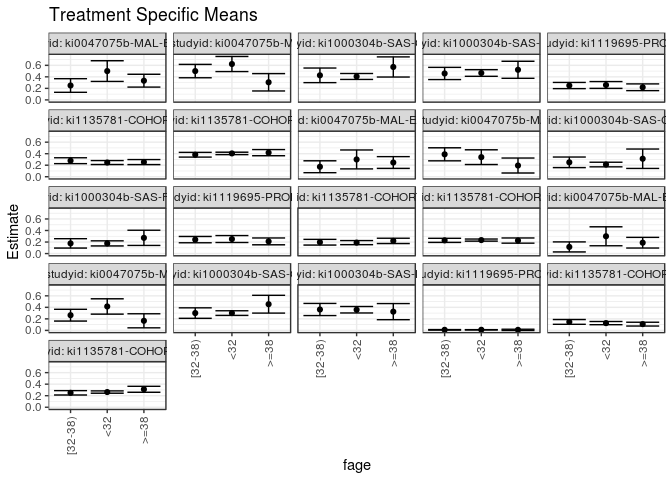

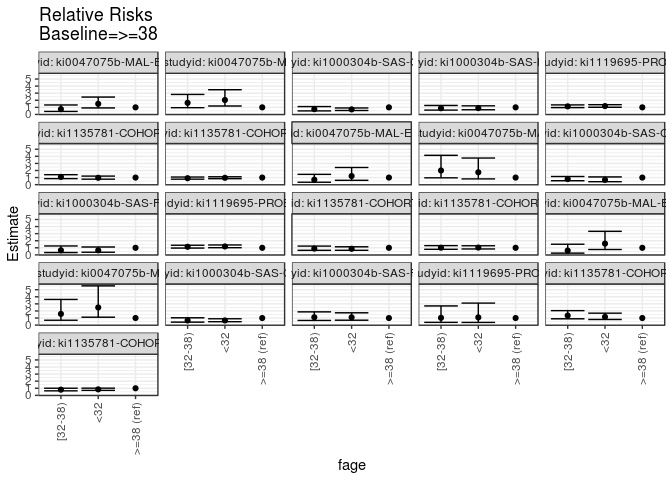

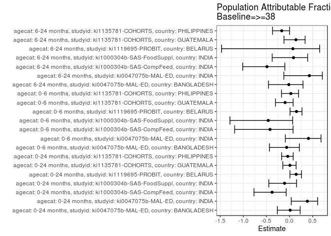

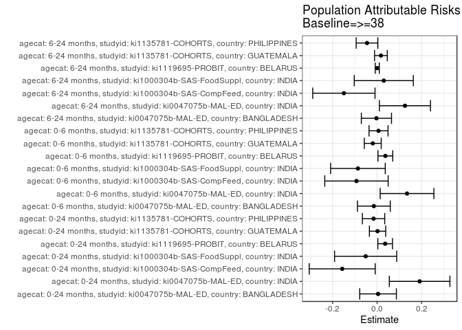

## Results Table

### Parameter: TSM

| agecat | studyid | country | intervention_level | baseline_level | estimate | ci_lower | ci_upper |
| --- | --- | --- | --- | --- | --- | --- | --- |
| 0-24 months | ki0047075b-MAL-ED | BANGLADESH | >=38 | NA | 0.3333333 | 0.2217344 | 0.4449323 |
| 0-24 months | ki0047075b-MAL-ED | BANGLADESH | <32 | NA | 0.5000000 | 0.3204852 | 0.6795148 |
| 0-24 months | ki0047075b-MAL-ED | BANGLADESH | [32-38) | NA | 0.2500000 | 0.1319163 | 0.3680837 |
| 0-24 months | ki0047075b-MAL-ED | INDIA | >=38 | NA | 0.3055556 | 0.1546123 | 0.4564988 |
| 0-24 months | ki0047075b-MAL-ED | INDIA | <32 | NA | 0.6226415 | 0.4917356 | 0.7535474 |
| 0-24 months | ki0047075b-MAL-ED | INDIA | [32-38) | NA | 0.5000000 | 0.3841477 | 0.6158523 |
| 0-24 months | ki1000304b-SAS-CompFeed | INDIA | >=38 | NA | 0.5714286 | 0.3964771 | 0.7463800 |
| 0-24 months | ki1000304b-SAS-CompFeed | INDIA | <32 | NA | 0.4066456 | 0.3554052 | 0.4578860 |
| 0-24 months | ki1000304b-SAS-CompFeed | INDIA | [32-38) | NA | 0.4263959 | 0.2997449 | 0.5530470 |
| 0-24 months | ki1000304b-SAS-FoodSuppl | INDIA | >=38 | NA | 0.5227273 | 0.3749653 | 0.6704893 |
| 0-24 months | ki1000304b-SAS-FoodSuppl | INDIA | <32 | NA | 0.4671280 | 0.4095378 | 0.5247182 |
| 0-24 months | ki1000304b-SAS-FoodSuppl | INDIA | [32-38) | NA | 0.4588235 | 0.3527637 | 0.5648834 |
| 0-24 months | ki1119695-PROBIT | BELARUS | >=38 | NA | 0.2190860 | 0.1605027 | 0.2776694 |
| 0-24 months | ki1119695-PROBIT | BELARUS | <32 | NA | 0.2586722 | 0.1993980 | 0.3179463 |
| 0-24 months | ki1119695-PROBIT | BELARUS | [32-38) | NA | 0.2492929 | 0.1953041 | 0.3032818 |
| 0-24 months | ki1135781-COHORTS | GUATEMALA | >=38 | NA | 0.2539267 | 0.2102620 | 0.2975914 |
| 0-24 months | ki1135781-COHORTS | GUATEMALA | <32 | NA | 0.2462562 | 0.2117986 | 0.2807139 |
| 0-24 months | ki1135781-COHORTS | GUATEMALA | [32-38) | NA | 0.2781457 | 0.2275895 | 0.3287019 |
| 0-24 months | ki1135781-COHORTS | PHILIPPINES | >=38 | NA | 0.4176829 | 0.3643017 | 0.4710641 |
| 0-24 months | ki1135781-COHORTS | PHILIPPINES | <32 | NA | 0.4045323 | 0.3834060 | 0.4256586 |
| 0-24 months | ki1135781-COHORTS | PHILIPPINES | [32-38) | NA | 0.3817505 | 0.3406538 | 0.4228471 |
| 0-6 months | ki0047075b-MAL-ED | BANGLADESH | >=38 | NA | 0.2463768 | 0.1443667 | 0.3483870 |
| 0-6 months | ki0047075b-MAL-ED | BANGLADESH | <32 | NA | 0.3000000 | 0.1354719 | 0.4645281 |
| 0-6 months | ki0047075b-MAL-ED | BANGLADESH | [32-38) | NA | 0.1730769 | 0.0699098 | 0.2762441 |
| 0-6 months | ki0047075b-MAL-ED | INDIA | >=38 | NA | 0.1944444 | 0.0647578 | 0.3241311 |
| 0-6 months | ki0047075b-MAL-ED | INDIA | <32 | NA | 0.3396226 | 0.2117265 | 0.4675188 |
| 0-6 months | ki0047075b-MAL-ED | INDIA | [32-38) | NA | 0.3888889 | 0.2759333 | 0.5018445 |
| 0-6 months | ki1000304b-SAS-CompFeed | INDIA | >=38 | NA | 0.3125000 | 0.1439976 | 0.4810024 |
| 0-6 months | ki1000304b-SAS-CompFeed | INDIA | <32 | NA | 0.2114467 | 0.1717146 | 0.2511788 |
| 0-6 months | ki1000304b-SAS-CompFeed | INDIA | [32-38) | NA | 0.2500000 | 0.1585512 | 0.3414488 |
| 0-6 months | ki1000304b-SAS-FoodSuppl | INDIA | >=38 | NA | 0.2727273 | 0.1409760 | 0.4044785 |
| 0-6 months | ki1000304b-SAS-FoodSuppl | INDIA | <32 | NA | 0.1764706 | 0.1324663 | 0.2204749 |
| 0-6 months | ki1000304b-SAS-FoodSuppl | INDIA | [32-38) | NA | 0.1764706 | 0.0953307 | 0.2576105 |
| 0-6 months | ki1119695-PROBIT | BELARUS | >=38 | NA | 0.2113055 | 0.1521053 | 0.2705058 |
| 0-6 months | ki1119695-PROBIT | BELARUS | <32 | NA | 0.2518955 | 0.1918724 | 0.3119187 |
| 0-6 months | ki1119695-PROBIT | BELARUS | [32-38) | NA | 0.2420202 | 0.1872853 | 0.2967551 |
| 0-6 months | ki1135781-COHORTS | GUATEMALA | >=38 | NA | 0.2200647 | 0.1738495 | 0.2662799 |
| 0-6 months | ki1135781-COHORTS | GUATEMALA | <32 | NA | 0.1897655 | 0.1542607 | 0.2252703 |
| 0-6 months | ki1135781-COHORTS | GUATEMALA | [32-38) | NA | 0.1967871 | 0.1473818 | 0.2461925 |
| 0-6 months | ki1135781-COHORTS | PHILIPPINES | >=38 | NA | 0.2256098 | 0.1803675 | 0.2708520 |
| 0-6 months | ki1135781-COHORTS | PHILIPPINES | <32 | NA | 0.2339604 | 0.2157333 | 0.2521876 |
| 0-6 months | ki1135781-COHORTS | PHILIPPINES | [32-38) | NA | 0.2290503 | 0.1935024 | 0.2645981 |
| 6-24 months | ki0047075b-MAL-ED | BANGLADESH | >=38 | NA | 0.1884058 | 0.0958331 | 0.2809785 |
| 6-24 months | ki0047075b-MAL-ED | BANGLADESH | <32 | NA | 0.3000000 | 0.1354719 | 0.4645281 |
| 6-24 months | ki0047075b-MAL-ED | BANGLADESH | [32-38) | NA | 0.1153846 | 0.0282601 | 0.2025091 |
| 6-24 months | ki0047075b-MAL-ED | INDIA | >=38 | NA | 0.1666667 | 0.0445476 | 0.2887858 |
| 6-24 months | ki0047075b-MAL-ED | INDIA | <32 | NA | 0.4150943 | 0.2820246 | 0.5481641 |
| 6-24 months | ki0047075b-MAL-ED | INDIA | [32-38) | NA | 0.2638889 | 0.1617674 | 0.3660104 |
| 6-24 months | ki1000304b-SAS-CompFeed | INDIA | >=38 | NA | 0.4545455 | 0.3001629 | 0.6089281 |
| 6-24 months | ki1000304b-SAS-CompFeed | INDIA | <32 | NA | 0.3002566 | 0.2601339 | 0.3403793 |
| 6-24 months | ki1000304b-SAS-CompFeed | INDIA | [32-38) | NA | 0.3005780 | 0.2093171 | 0.3918390 |
| 6-24 months | ki1000304b-SAS-FoodSuppl | INDIA | >=38 | NA | 0.3255814 | 0.1853487 | 0.4658141 |
| 6-24 months | ki1000304b-SAS-FoodSuppl | INDIA | <32 | NA | 0.3584229 | 0.3020839 | 0.4147619 |
| 6-24 months | ki1000304b-SAS-FoodSuppl | INDIA | [32-38) | NA | 0.3625000 | 0.2570278 | 0.4679722 |
| 6-24 months | ki1119695-PROBIT | BELARUS | >=38 | NA | 0.0095238 | -0.0012136 | 0.0202612 |
| 6-24 months | ki1119695-PROBIT | BELARUS | <32 | NA | 0.0103833 | 0.0077464 | 0.0130202 |
| 6-24 months | ki1119695-PROBIT | BELARUS | [32-38) | NA | 0.0098039 | 0.0053467 | 0.0142611 |
| 6-24 months | ki1135781-COHORTS | GUATEMALA | >=38 | NA | 0.1088235 | 0.0757075 | 0.1419396 |
| 6-24 months | ki1135781-COHORTS | GUATEMALA | <32 | NA | 0.1263736 | 0.0984913 | 0.1542560 |
| 6-24 months | ki1135781-COHORTS | GUATEMALA | [32-38) | NA | 0.1469534 | 0.1053902 | 0.1885166 |
| 6-24 months | ki1135781-COHORTS | PHILIPPINES | >=38 | NA | 0.3114754 | 0.2594938 | 0.3634570 |
| 6-24 months | ki1135781-COHORTS | PHILIPPINES | <32 | NA | 0.2632130 | 0.2434650 | 0.2829609 |
| 6-24 months | ki1135781-COHORTS | PHILIPPINES | [32-38) | NA | 0.2500000 | 0.2121894 | 0.2878106 |

### Parameter: E(Y)

| agecat | studyid | country | intervention_level | baseline_level | estimate | ci_lower | ci_upper |
| --- | --- | --- | --- | --- | --- | --- | --- |
| 0-24 months | ki0047075b-MAL-ED | BANGLADESH | NA | NA | 0.3377483 | 0.2620632 | 0.4134335 |
| 0-24 months | ki0047075b-MAL-ED | INDIA | NA | NA | 0.4968944 | 0.4194215 | 0.5743673 |
| 0-24 months | ki1000304b-SAS-CompFeed | INDIA | NA | NA | 0.4145695 | 0.3576236 | 0.4715155 |
| 0-24 months | ki1000304b-SAS-FoodSuppl | INDIA | NA | NA | 0.4712919 | 0.4233811 | 0.5192026 |
| 0-24 months | ki1119695-PROBIT | BELARUS | NA | NA | 0.2554368 | 0.1979772 | 0.3128964 |
| 0-24 months | ki1135781-COHORTS | GUATEMALA | NA | NA | 0.2560311 | 0.2321591 | 0.2799032 |
| 0-24 months | ki1135781-COHORTS | PHILIPPINES | NA | NA | 0.4018374 | 0.3841095 | 0.4195652 |
| 0-6 months | ki0047075b-MAL-ED | BANGLADESH | NA | NA | 0.2317881 | 0.1642594 | 0.2993168 |
| 0-6 months | ki0047075b-MAL-ED | INDIA | NA | NA | 0.3291925 | 0.2563790 | 0.4020061 |
| 0-6 months | ki1000304b-SAS-CompFeed | INDIA | NA | NA | 0.2197071 | 0.1750081 | 0.2644060 |
| 0-6 months | ki1000304b-SAS-FoodSuppl | INDIA | NA | NA | 0.1866029 | 0.1492099 | 0.2239959 |
| 0-6 months | ki1119695-PROBIT | BELARUS | NA | NA | 0.2485407 | 0.1903207 | 0.3067607 |
| 0-6 months | ki1135781-COHORTS | GUATEMALA | NA | NA | 0.2005842 | 0.1760818 | 0.2250867 |
| 0-6 months | ki1135781-COHORTS | PHILIPPINES | NA | NA | 0.2321307 | 0.2168619 | 0.2473995 |
| 6-24 months | ki0047075b-MAL-ED | BANGLADESH | NA | NA | 0.1854305 | 0.1232352 | 0.2476257 |
| 6-24 months | ki0047075b-MAL-ED | INDIA | NA | NA | 0.2919255 | 0.2214783 | 0.3623726 |
| 6-24 months | ki1000304b-SAS-CompFeed | INDIA | NA | NA | 0.3051948 | 0.2633957 | 0.3469939 |
| 6-24 months | ki1000304b-SAS-FoodSuppl | INDIA | NA | NA | 0.3557214 | 0.3088651 | 0.4025777 |
| 6-24 months | ki1119695-PROBIT | BELARUS | NA | NA | 0.0102551 | 0.0075905 | 0.0129198 |
| 6-24 months | ki1135781-COHORTS | GUATEMALA | NA | NA | 0.1261803 | 0.1071047 | 0.1452559 |
| 6-24 months | ki1135781-COHORTS | PHILIPPINES | NA | NA | 0.2661765 | 0.2495644 | 0.2827886 |

### Parameter: RR

| agecat | studyid | country | intervention_level | baseline_level | estimate | ci_lower | ci_upper |
| --- | --- | --- | --- | --- | --- | --- | --- |
| 0-24 months | ki0047075b-MAL-ED | BANGLADESH | >=38 | >=38 | 1.0000000 | 1.0000000 | 1.0000000 |
| 0-24 months | ki0047075b-MAL-ED | BANGLADESH | <32 | >=38 | 1.5000000 | 0.9181050 | 2.4507000 |
| 0-24 months | ki0047075b-MAL-ED | BANGLADESH | [32-38) | >=38 | 0.7500000 | 0.4203628 | 1.3381299 |
| 0-24 months | ki0047075b-MAL-ED | INDIA | >=38 | >=38 | 1.0000000 | 1.0000000 | 1.0000000 |
| 0-24 months | ki0047075b-MAL-ED | INDIA | <32 | >=38 | 2.0377358 | 1.1912044 | 3.4858562 |
| 0-24 months | ki0047075b-MAL-ED | INDIA | [32-38) | >=38 | 1.6363636 | 0.9482283 | 2.8238831 |
| 0-24 months | ki1000304b-SAS-CompFeed | INDIA | >=38 | >=38 | 1.0000000 | 1.0000000 | 1.0000000 |
| 0-24 months | ki1000304b-SAS-CompFeed | INDIA | <32 | >=38 | 0.7116297 | 0.5533881 | 0.9151206 |
| 0-24 months | ki1000304b-SAS-CompFeed | INDIA | [32-38) | >=38 | 0.7461929 | 0.5014103 | 1.1104755 |
| 0-24 months | ki1000304b-SAS-FoodSuppl | INDIA | >=38 | >=38 | 1.0000000 | 1.0000000 | 1.0000000 |
| 0-24 months | ki1000304b-SAS-FoodSuppl | INDIA | <32 | >=38 | 0.8936362 | 0.6564907 | 1.2164464 |
| 0-24 months | ki1000304b-SAS-FoodSuppl | INDIA | [32-38) | >=38 | 0.8777494 | 0.6092361 | 1.2646066 |
| 0-24 months | ki1119695-PROBIT | BELARUS | >=38 | >=38 | 1.0000000 | 1.0000000 | 1.0000000 |
| 0-24 months | ki1119695-PROBIT | BELARUS | <32 | >=38 | 1.1806877 | 1.0131435 | 1.3759390 |
| 0-24 months | ki1119695-PROBIT | BELARUS | [32-38) | >=38 | 1.1378769 | 0.9638161 | 1.3433724 |
| 0-24 months | ki1135781-COHORTS | GUATEMALA | >=38 | >=38 | 1.0000000 | 1.0000000 | 1.0000000 |
| 0-24 months | ki1135781-COHORTS | GUATEMALA | <32 | >=38 | 0.9697926 | 0.7769586 | 1.2104863 |
| 0-24 months | ki1135781-COHORTS | GUATEMALA | [32-38) | >=38 | 1.0953779 | 0.8528990 | 1.4067934 |
| 0-24 months | ki1135781-COHORTS | PHILIPPINES | >=38 | >=38 | 1.0000000 | 1.0000000 | 1.0000000 |
| 0-24 months | ki1135781-COHORTS | PHILIPPINES | <32 | >=38 | 0.9685153 | 0.8436205 | 1.1119003 |
| 0-24 months | ki1135781-COHORTS | PHILIPPINES | [32-38) | >=38 | 0.9139719 | 0.7733243 | 1.0801996 |
| 0-6 months | ki0047075b-MAL-ED | BANGLADESH | >=38 | >=38 | 1.0000000 | 1.0000000 | 1.0000000 |
| 0-6 months | ki0047075b-MAL-ED | BANGLADESH | <32 | >=38 | 1.2176471 | 0.6124737 | 2.4207805 |
| 0-6 months | ki0047075b-MAL-ED | BANGLADESH | [32-38) | >=38 | 0.7024887 | 0.3399717 | 1.4515632 |
| 0-6 months | ki0047075b-MAL-ED | INDIA | >=38 | >=38 | 1.0000000 | 1.0000000 | 1.0000000 |
| 0-6 months | ki0047075b-MAL-ED | INDIA | <32 | >=38 | 1.7466307 | 0.8120101 | 3.7569961 |
| 0-6 months | ki0047075b-MAL-ED | INDIA | [32-38) | >=38 | 2.0000000 | 0.9662673 | 4.1396415 |
| 0-6 months | ki1000304b-SAS-CompFeed | INDIA | >=38 | >=38 | 1.0000000 | 1.0000000 | 1.0000000 |
| 0-6 months | ki1000304b-SAS-CompFeed | INDIA | <32 | >=38 | 0.6766296 | 0.4192782 | 1.0919423 |
| 0-6 months | ki1000304b-SAS-CompFeed | INDIA | [32-38) | >=38 | 0.8000000 | 0.5563974 | 1.1502571 |
| 0-6 months | ki1000304b-SAS-FoodSuppl | INDIA | >=38 | >=38 | 1.0000000 | 1.0000000 | 1.0000000 |
| 0-6 months | ki1000304b-SAS-FoodSuppl | INDIA | <32 | >=38 | 0.6470588 | 0.3756993 | 1.1144154 |
| 0-6 months | ki1000304b-SAS-FoodSuppl | INDIA | [32-38) | >=38 | 0.6470588 | 0.3321267 | 1.2606188 |
| 0-6 months | ki1119695-PROBIT | BELARUS | >=38 | >=38 | 1.0000000 | 1.0000000 | 1.0000000 |
| 0-6 months | ki1119695-PROBIT | BELARUS | <32 | >=38 | 1.1920916 | 1.0161324 | 1.3985209 |
| 0-6 months | ki1119695-PROBIT | BELARUS | [32-38) | >=38 | 1.1453568 | 0.9635900 | 1.3614110 |
| 0-6 months | ki1135781-COHORTS | GUATEMALA | >=38 | >=38 | 1.0000000 | 1.0000000 | 1.0000000 |
| 0-6 months | ki1135781-COHORTS | GUATEMALA | <32 | >=38 | 0.8623166 | 0.6509022 | 1.1423987 |
| 0-6 months | ki1135781-COHORTS | GUATEMALA | [32-38) | >=38 | 0.8942240 | 0.6446083 | 1.2404997 |
| 0-6 months | ki1135781-COHORTS | PHILIPPINES | >=38 | >=38 | 1.0000000 | 1.0000000 | 1.0000000 |
| 0-6 months | ki1135781-COHORTS | PHILIPPINES | <32 | >=38 | 1.0370139 | 0.8362818 | 1.2859275 |
| 0-6 months | ki1135781-COHORTS | PHILIPPINES | [32-38) | >=38 | 1.0152499 | 0.7878569 | 1.3082735 |
| 6-24 months | ki0047075b-MAL-ED | BANGLADESH | >=38 | >=38 | 1.0000000 | 1.0000000 | 1.0000000 |
| 6-24 months | ki0047075b-MAL-ED | BANGLADESH | <32 | >=38 | 1.5923077 | 0.7624990 | 3.3251767 |
| 6-24 months | ki0047075b-MAL-ED | BANGLADESH | [32-38) | >=38 | 0.6124260 | 0.2487773 | 1.5076363 |
| 6-24 months | ki0047075b-MAL-ED | INDIA | >=38 | >=38 | 1.0000000 | 1.0000000 | 1.0000000 |
| 6-24 months | ki0047075b-MAL-ED | INDIA | <32 | >=38 | 2.4905660 | 1.1193351 | 5.5416104 |
| 6-24 months | ki0047075b-MAL-ED | INDIA | [32-38) | >=38 | 1.5833333 | 0.6913573 | 3.6261201 |
| 6-24 months | ki1000304b-SAS-CompFeed | INDIA | >=38 | >=38 | 1.0000000 | 1.0000000 | 1.0000000 |
| 6-24 months | ki1000304b-SAS-CompFeed | INDIA | <32 | >=38 | 0.6605646 | 0.4845854 | 0.9004514 |
| 6-24 months | ki1000304b-SAS-CompFeed | INDIA | [32-38) | >=38 | 0.6612717 | 0.4228096 | 1.0342249 |
| 6-24 months | ki1000304b-SAS-FoodSuppl | INDIA | >=38 | >=38 | 1.0000000 | 1.0000000 | 1.0000000 |
| 6-24 months | ki1000304b-SAS-FoodSuppl | INDIA | <32 | >=38 | 1.1008705 | 0.6960045 | 1.7412469 |
| 6-24 months | ki1000304b-SAS-FoodSuppl | INDIA | [32-38) | >=38 | 1.1133929 | 0.6620804 | 1.8723462 |
| 6-24 months | ki1119695-PROBIT | BELARUS | >=38 | >=38 | 1.0000000 | 1.0000000 | 1.0000000 |
| 6-24 months | ki1119695-PROBIT | BELARUS | <32 | >=38 | 1.0902490 | 0.3822067 | 3.1099478 |
| 6-24 months | ki1119695-PROBIT | BELARUS | [32-38) | >=38 | 1.0294118 | 0.3913001 | 2.7081224 |
| 6-24 months | ki1135781-COHORTS | GUATEMALA | >=38 | >=38 | 1.0000000 | 1.0000000 | 1.0000000 |
| 6-24 months | ki1135781-COHORTS | GUATEMALA | <32 | >=38 | 1.1612712 | 0.7974293 | 1.6911226 |
| 6-24 months | ki1135781-COHORTS | GUATEMALA | [32-38) | >=38 | 1.3503826 | 0.8913112 | 2.0458997 |
| 6-24 months | ki1135781-COHORTS | PHILIPPINES | >=38 | >=38 | 1.0000000 | 1.0000000 | 1.0000000 |
| 6-24 months | ki1135781-COHORTS | PHILIPPINES | <32 | >=38 | 0.8450522 | 0.7037485 | 1.0147278 |
| 6-24 months | ki1135781-COHORTS | PHILIPPINES | [32-38) | >=38 | 0.8026316 | 0.6407707 | 1.0053791 |

### Parameter: PAR

| agecat | studyid | country | intervention_level | baseline_level | estimate | ci_lower | ci_upper |
| --- | --- | --- | --- | --- | --- | --- | --- |
| 0-24 months | ki0047075b-MAL-ED | BANGLADESH | >=38 | NA | 0.0044150 | -0.0780499 | 0.0868800 |
| 0-24 months | ki0047075b-MAL-ED | INDIA | >=38 | NA | 0.1913389 | 0.0549686 | 0.3277091 |
| 0-24 months | ki1000304b-SAS-CompFeed | INDIA | >=38 | NA | -0.1568590 | -0.3052638 | -0.0084543 |
| 0-24 months | ki1000304b-SAS-FoodSuppl | INDIA | >=38 | NA | -0.0514354 | -0.1911941 | 0.0883233 |
| 0-24 months | ki1119695-PROBIT | BELARUS | >=38 | NA | 0.0363508 | 0.0034201 | 0.0692814 |
| 0-24 months | ki1135781-COHORTS | GUATEMALA | >=38 | NA | 0.0021044 | -0.0345412 | 0.0387501 |
| 0-24 months | ki1135781-COHORTS | PHILIPPINES | >=38 | NA | -0.0158456 | -0.0661227 | 0.0344316 |
| 0-6 months | ki0047075b-MAL-ED | BANGLADESH | >=38 | NA | -0.0145887 | -0.0884536 | 0.0592761 |
| 0-6 months | ki0047075b-MAL-ED | INDIA | >=38 | NA | 0.1347481 | 0.0139215 | 0.2555747 |
| 0-6 months | ki1000304b-SAS-CompFeed | INDIA | >=38 | NA | -0.0927929 | -0.2353716 | 0.0497857 |
| 0-6 months | ki1000304b-SAS-FoodSuppl | INDIA | >=38 | NA | -0.0861244 | -0.2090156 | 0.0367667 |
| 0-6 months | ki1119695-PROBIT | BELARUS | >=38 | NA | 0.0372352 | 0.0040299 | 0.0704404 |
| 0-6 months | ki1135781-COHORTS | GUATEMALA | >=38 | NA | -0.0194805 | -0.0575720 | 0.0186110 |
| 0-6 months | ki1135781-COHORTS | PHILIPPINES | >=38 | NA | 0.0065209 | -0.0361753 | 0.0492172 |
| 6-24 months | ki0047075b-MAL-ED | BANGLADESH | >=38 | NA | -0.0029753 | -0.0708431 | 0.0648925 |
| 6-24 months | ki0047075b-MAL-ED | INDIA | >=38 | NA | 0.1252588 | 0.0103385 | 0.2401791 |
| 6-24 months | ki1000304b-SAS-CompFeed | INDIA | >=38 | NA | -0.1493506 | -0.2894278 | -0.0092735 |
| 6-24 months | ki1000304b-SAS-FoodSuppl | INDIA | >=38 | NA | 0.0301400 | -0.1027274 | 0.1630073 |
| 6-24 months | ki1119695-PROBIT | BELARUS | >=38 | NA | 0.0007313 | -0.0085038 | 0.0099664 |
| 6-24 months | ki1135781-COHORTS | GUATEMALA | >=38 | NA | 0.0173567 | -0.0112865 | 0.0459999 |
| 6-24 months | ki1135781-COHORTS | PHILIPPINES | >=38 | NA | -0.0452989 | -0.0940028 | 0.0034049 |

### Parameter: PAF

| agecat | studyid | country | intervention_level | baseline_level | estimate | ci_lower | ci_upper |
| --- | --- | --- | --- | --- | --- | --- | --- |
| 0-24 months | ki0047075b-MAL-ED | BANGLADESH | >=38 | NA | 0.0130719 | -0.2639438 | 0.2293747 |
| 0-24 months | ki0047075b-MAL-ED | INDIA | >=38 | NA | 0.3850694 | 0.0369563 | 0.6073495 |
| 0-24 months | ki1000304b-SAS-CompFeed | INDIA | >=38 | NA | -0.3783660 | -0.7704978 | -0.0730841 |
| 0-24 months | ki1000304b-SAS-FoodSuppl | INDIA | >=38 | NA | -0.1091371 | -0.4493709 | 0.1512283 |
| 0-24 months | ki1119695-PROBIT | BELARUS | >=38 | NA | 0.1423083 | 0.0080226 | 0.2584155 |
| 0-24 months | ki1135781-COHORTS | GUATEMALA | >=38 | NA | 0.0082194 | -0.1457526 | 0.1414999 |
| 0-24 months | ki1135781-COHORTS | PHILIPPINES | >=38 | NA | -0.0394328 | -0.1723982 | 0.0784526 |
| 0-6 months | ki0047075b-MAL-ED | BANGLADESH | >=38 | NA | -0.0629400 | -0.4342828 | 0.2122604 |
| 0-6 months | ki0047075b-MAL-ED | INDIA | >=38 | NA | 0.4093291 | -0.0907885 | 0.6801469 |
| 0-6 months | ki1000304b-SAS-CompFeed | INDIA | >=38 | NA | -0.4223485 | -1.1882409 | 0.0754787 |
| 0-6 months | ki1000304b-SAS-FoodSuppl | INDIA | >=38 | NA | -0.4615385 | -1.2901662 | 0.0672753 |
| 0-6 months | ki1119695-PROBIT | BELARUS | >=38 | NA | 0.1498153 | 0.0103120 | 0.2696546 |
| 0-6 months | ki1135781-COHORTS | GUATEMALA | >=38 | NA | -0.0971188 | -0.3042497 | 0.0771172 |
| 0-6 months | ki1135781-COHORTS | PHILIPPINES | >=38 | NA | 0.0280917 | -0.1743920 | 0.1956640 |
| 6-24 months | ki0047075b-MAL-ED | BANGLADESH | >=38 | NA | -0.0160455 | -0.4566198 | 0.2912711 |
| 6-24 months | ki0047075b-MAL-ED | INDIA | >=38 | NA | 0.4290780 | -0.1233081 | 0.7098286 |
| 6-24 months | ki1000304b-SAS-CompFeed | INDIA | >=38 | NA | -0.4893617 | -1.0142886 | -0.1012316 |
| 6-24 months | ki1000304b-SAS-FoodSuppl | INDIA | >=38 | NA | 0.0847292 | -0.3765209 | 0.3914218 |
| 6-24 months | ki1119695-PROBIT | BELARUS | >=38 | NA | 0.0713124 | -1.4722970 | 0.6511501 |
| 6-24 months | ki1135781-COHORTS | GUATEMALA | >=38 | NA | 0.1375550 | -0.1211929 | 0.3365893 |
| 6-24 months | ki1135781-COHORTS | PHILIPPINES | >=38 | NA | -0.1701839 | -0.3681864 | -0.0008360 |